# Navigating menopause at work: A preliminary study about challenges and support systems

Data pre-processing and data analysis report

Alzueta, E., Menghini, L., Volpe L., Baker, F. C., Garnier A., Sarrel P. M., de Zambotti, M.

# Aims and content

The present document includes the data pre-processing and data analysis steps conducted to explore **the individual and work-related correlates of menopause experience at work**. The data were collected with an online survey available both in English and Spanish from February 1st to August 9th 2023, implemented with the [REDCap survey platform](https://www.project-redcap.org/).

In the following sections, we read and recode the data exported from REDCap, we apply our exclusion criteria, we evaluate the psychometric qualities of the considered measures, we compute descriptive statistics, and we conduct regression analyses.

Through the document, each step is accompanied by the corresponding R code, as in the following example where we remove all objects from the R global environment. However, in the following section the code is hidden (or ‘folded’) and the “Show” button should be clicked to visualized it. Each line of code is described by a comment preceded by the `#` symbol.

```r
rm(list=ls()) # removing all objets from the workspace
```

The following R packages are used in this document (see References section):

```r
# required packages
packages <- c("labourR","data.table","magrittr","plyr","ggplot2","gridExtra","Rmisc","Hmisc")

# generate packages references
knitr::write_bib(c(.packages(), packages),"packages.bib")
```

```
## tweaking Hmisc
```

```r
# # run to install missing packages
# xfun::pkg_attach2(packages, message = FALSE); rm(list=ls())
```

# 1. Data reading

First, we read the raw `mp` data exported from REDCap on August 9th 2023. Note that the same information is separately included for the English and the Spanish version of the questionnaire.

```r
# loading preliminary questionnaire data
mp <- read.csv("data/MenopauseInTheWorkpl-FullExport_DATA_2023-08-09_0932.csv")

# sample size and number of columns/variables
cat("Read",nrow(mp),"responses;",ncol(mp),"variables")
```

```
## Read 1000 responses; 227 variables
```

# 2. Data recoding

Here, we prepare the data for the following analyses by selecting the considered variables and recoding their values.

## 2.1. Language

First, we merge the columns related to the English version of the questionnaire (ending with `_en`) with the corresponding Spanish item versions (ending with `_es`). The number of columns is now 116.

```r
# recoding language
mp$language <- as.factor(gsub("1","en",gsub("2","es",mp$language))) # 1 = en, 2 = es

# merging English and Spanish responses
for(i in 1:ncol(mp)){
  if(grepl("_es",colnames(mp)[i])){
    mp[!is.na(mp$language) &
         mp$language=="es",colnames(mp)[which(colnames(mp)==gsub("_es","_en",colnames(mp)[i]))]] <-
      mp[!is.na(mp$language) & mp$language=="es",colnames(mp)[i]] }} # moving es to en when language = "es"
mp <- mp[,!grepl("_es",colnames(mp))] # removing all columns referred to Spanish responses
colnames(mp) <- gsub("_en","",colnames(mp))

# updated No. of columns/variables
cat("Updated No. of variables:",ncol(mp))
```

```
## Updated No. of variables: 116
```

## 2.2. Categorical variables

Second, we recode all categorical variables by converting numerical values into the corresponding response labels. Particularly, for the `country` variable we use an external file reporting the whole list of countries and the corresponding numerical value.

```r
# ...............................recoding demographics
countries <- read.csv2("data/countries.csv") # countries (note: removed "Azerbaijan" due to gap in data encoding)
head(countries) # showing first lines
```

|  | country | number |
| --- | --- | --- |
| 1 | Afghanistan | 1 |
| 2 | Albania | 2 |
| 3 | Algeria | 3 |
| 4 | American Samoa | 4 |
| 5 | Andorra | 5 |
| 6 | Angola | 6 |

```r
for(i in 1:nrow(countries)){
  mp[!is.na(mp$country) & mp$country==countries[i,"number"],"country"] <- countries[i,"country"] }
mp$ethnicity <- gsub("1","Hispanic/Latino", # ethnicity
                     gsub("2","Not Hispanic/Latino",
                          gsub("3","Unknown",
                               gsub("4","NS",mp$ethnicity))))
mp$race <- gsub("1","Native", # race
                    gsub("2","Asian",
                         gsub("3","Black",
                              gsub("4","Native Pacific",
                                   gsub("5","White",
                                        gsub("6","Unknown",
                                             gsub("7","NS",mp$race)))))))
mp$gender <- gsub("1","Woman", # gender
                  gsub("2","Non-binary",
                       gsub("3","Transgender woman",
                            gsub("4","Transgender man",
                                 gsub("5","NS",mp$gender))))) # gender
colnames(mp)[which(colnames(mp)=="highest_education")] <- "education"
mp$education <- gsub("1","Primary_some", # education
                     gsub("2","Primary_complete",
                          gsub("3","Secondary",
                               gsub("4","Training",
                                    gsub("5","Undergraduate",
                                         gsub("6","Postgraduate",mp$education))))))
colnames(mp)[which(colnames(mp)=="relationship_status")] <- "partner"
mp$partner <- gsub("1","Yes",gsub("2","No",mp$partner)) # partner
mp$childcare <- gsub("1","Yes",gsub("0","No",mp$childcare)) # childcare
mp$caregiver <- gsub("1","Yes",gsub("0","No",mp$caregiver)) # caregiver

# ...............................recoding lifestyle
mp$health_conditions <- gsub("1","Yes",gsub("0","No",mp$health_conditions)) # health_conditions
mp$tobacco <- gsub("1","Yes",gsub("0","No",mp$tobacco)) # tobacco

# ...............................recoding reproductive history
mp$period_change <- gsub("1","No changes (regular)", # period_change
                         gsub("2","No changes (irregular)",
                              gsub("3","Changes to irregular",
                                   gsub("4","Not sure",
                                        gsub("5","NS",mp$period_change)))))
mp$oophorectomy <- gsub("0","Never",gsub("1","Once",gsub("2","Twice",mp$oophorectomy))) # oophorectomy
mp$hysterectomy <- gsub("1","Yes",gsub("0","No",mp$hysterectomy)) # hysterectomy

# ...............................recoding job variables
mp$job_level <- gsub("1","Self-employed", # job
                     gsub("2","Executive",
                          gsub("3","Manager",
                               gsub("4","Employee",
                                    gsub("5","Other",mp$job_level)))))
colnames(mp)[which(colnames(mp)=="on_call")] <- "NightShift_onCall"
mp$NightShift_onCall <- gsub("1","Yes",gsub("0","No",mp$NightShift_onCall)) # work extended availability
mp$remote_work <- gsub("1","Remote",gsub("2","Hybrid",gsub("3","Onsite",mp$remote_work))) # remote_work

# recoding all categorical variables as factor
factors <- c("record_id","language","country","race","ethnicity","gender","education","partner","childcare","caregiver",
             "health_conditions","tobacco","period_change","oophorectomy","hysterectomy",
             paste0("reproductive_specifics___",0:5),
             "job_level","NightShift_onCall","remote_work",
             paste0("work_problems___",1:9),paste0(rep(paste0("measures_",1:9),each=2),"___",1:2),
             paste0("discussion_concerns___",c(1:9,0)),"currency")
mp[,factors] <- lapply(mp[,factors],as.factor)
```

### 2.3.1. Recoding jobs

Here, we recode the `job` variable by using the `labourR` package and some manual correction. We also create the `retired` variable to flag participants that reported being retired.

```r
# creating retired variable
mp$retired <- FALSE
mp[!is.na(mp$job) & gsub(" ","",mp$job)%in%c("Retired","retired"),"retired"] <- TRUE
mp[mp$retired==TRUE,"job"] <- NA # removing job value when retired = TRUE
mp[!is.na(mp$job) & mp$job=="","job"] <- NA # empty values as NA

# recoding jobs based on labourR
library(labourR); library(data.table); library(magrittr); library(plyr)
corpus <- data.table(id=mp$record_id,text=mp$job,language=mp$language) # creating corpus
languages <- as.character(na.omit(unique(corpus$language))) # language classes
suggestions <- lapply(languages, function(lang) { # automatic classification
  classify_occupation(corpus=corpus[corpus$language==lang],lang=lang,isco_level=2,num_leaves=10) }) %>%
  rbindlist
corpus <- plyr::join(corpus,suggestions,by="id",type="left")

# manually adjusting automatic classifications
corpus$text <- gsub(" ","",corpus$text) # removing space
corpus[!is.na(corpus$text) & corpus$text%in%c("BusinessOwner","Businessowner","ExecutiveDirector",
                                              "NonprofitExecutiveDirector","nonprofitexec","SVP",
                                              "CountyExecutive","marketingagencyowner/operator",
                                              "CXO","ceo-softwarecompany","ExecutiveTeamLeader",
                                              "startupfounder","founderofatechcompany","nonprofitexecutive"),
       "preferredLabel"] <- "Chief executives, senior officials and legislators"
corpus[!is.na(corpus$text) & corpus$text%in%c("medicalofficer"),
       "preferredLabel"] <- "Health professionals"
corpus[!is.na(corpus$text) & corpus$text%in%c("HumanResources","humanresources","HR","supervisor","SalesDirector"),
       "preferredLabel"] <- "Administrative and Commercial Managers"
corpus[!is.na(corpus$text) & corpus$text%in%c("Volunteercoordinator","Volunteer","Nonprofit","filmdesigner","proofreader",
                                              "TechnicalWritet"),
       "preferredLabel"] <- "Legal, Social and Cultural Professionals"
corpus[!is.na(corpus$text) & corpus$text%in%c("shiftsupervisor"),
       "preferredLabel"] <- "Production and Specialised Services Managers"
corpus[!is.na(corpus$text) & corpus$text%in%c("Publichealthcommunications","headofmarketing","CorporateEventManager",
                                              "Administración","administrativo",
                        "Corporateeventproducer","Educationadministrator","administration","proj.admin","Marketing",
                        "Administrativo","administrator","contadoraindependiente","Accountant"),
       "preferredLabel"] <- "Business and Administration Associate Professionals"
corpus[!is.na(corpus$text) & corpus$text%in%c("Scientist","scientist","Researcher","researcher","researchscientist",
                                              "Researchdirector","Researrch","Research","research","LabManager"),
       "preferredLabel"] <- "Science and Engineering Professionals"
corpus[!is.na(corpus$text) & corpus$text%in%c("Researchassistamt"),
       "preferredLabel"] <- "Science and Engineering Associate Professionals"
corpus[!is.na(corpus$text) & corpus$text%in%c("collegeadvisor","headofdepartmentacademia","Principal","SLP"),
       "preferredLabel"] <- "Teaching professionals"
corpus[!is.na(corpus$text) & corpus$text%in%c("Landlord"),
       "preferredLabel"] <- "Hospitality, Retail and Other Services Managers"
corpus[!is.na(corpus$text) & corpus$text%in%c("clinician","medico","Medico","Médica","medicoespecialista","Clinical",
                                              "Physician","Primarycarephysician","Médicoradiologa"),
       "preferredLabel"] <- "Health Professionals"
corpus[!is.na(corpus$text) & corpus$text%in%c("asiantuntijasairaanhoitaja","Healthcareassistant",
                                              "RespiratoryCarepractitioner","PatientAccess","Nursepractitioner"),
       "preferredLabel"] <- "Health Associate Professionals"
corpus[!is.na(corpus$text) & corpus$text%in%c("highereducationadministration","administrativo"),
       "preferredLabel"] <- "Business and Administration Associate Professionals"
corpus[!is.na(corpus$text) & corpus$text%in%c("Sales","sales","Customersservice","Agentedeventas","VA"),
       "preferredLabel"] <- "Sales Workers"
corpus[!is.na(corpus$text) & corpus$text%in%c("Amadecasa","housewife","Homemaker"),
       "preferredLabel"] <- "Cleaners and Helpers"
corpus[!is.na(corpus$text) & corpus$text%in%c("uxresearch","Itprofessional","IT"),
       "preferredLabel"] <- "Information and Communications Technology Professionals"
corpus[!is.na(corpus$text) & corpus$text%in%c("Secretary","auxiliarcontable"),
       "preferredLabel"] <- "Numerical and Material Recording Clerks"
corpus[!is.na(corpus$text) & corpus$text%in%c("architect"),
       "preferredLabel"] <- "Production and Specialized Services Managers"
mp$job_recoded <- as.factor(tolower(corpus$preferredLabel)) # job as factor
mp <- mp[,c(1:which(colnames(mp)=="job"),ncol(mp)-1,ncol(mp),(which(colnames(mp)=="job")+1):(ncol(mp)-2))]

# showing first lines
mp[!is.na(mp$job_recoded),c("job","job_recoded")]
```

|  | job | job_recoded |
| --- | --- | --- |
| 9 | researcher | science and engineering professionals |
| 13 | teacher | teaching professionals |
| 18 | manager | production and specialised services managers |
| 23 | researcher | science and engineering professionals |
| 24 | manager | production and specialised services managers |
| 57 | Product leader | administrative and commercial managers |
| 68 | Postdoctoral research fellow | teaching professionals |
| 70 | data scientist | information and communications technology professionals |
| 82 | nurse | health professionals |
| 85 | Psychologist | legal, social and cultural professionals |

[output cut: 456 more lines]

## 2.3. Other variables

Third, we recode other variables (e.g., Boolean variables, date variables), and we remove the variables that are not considered for the present work. We rename the included variables and replace missing values with `NA` for multi-choice items. Below we print the names of the included variables.

```r
# Boolean as logical
mp$informed_consent <- as.logical(mp$informed_consent)
mp$survey_complete <- as.logical(mp$survey_complete)

# Time variables as dates or as.POSIXct
 mp[mp$survey_timestamp=="[not completed]","survey_timestamp"] <- NA # empty and [not completed] as missing
mp[mp$period_last_date=="","period_last_date"] <- NA
mp$survey_timestamp <- # adjusting date format
  as.POSIXct(gsub("/23","/2023",gsub("/22","/2022",gsub("\\.","\\:",mp$survey_timestamp))),format="%Y-%m-%d %H:%M:%S")
mp$period_last_date <- as.Date(gsub("0520","2020",gsub("1120","2020",mp$period_last_date)),format="%Y-%m-%d")

# Removing variables not considered
mp[,c("redcap_survey_identifier","survey_complete","job","currency","money_spent")] <- NULL

# renaming variables
colnames(mp) <- c("ID","survey_timestamp","language","informed_consent", # response info
                  "age","country","race","ethnicity","gender","education","partner","childcare","caregiver", # demograph
                  "health_conditions","tobacco","exercise", # lifestyle
                  "period_number","period_change","period_last_date", # periods info
                  paste0("rs_",c("oophor","hyster", # reproductive specifics
                  "postMP_medical","horm_birthCtrl","MP_hormTheraphy","periodStop_medical","pregnantBreast","none")),
                  "MP_knowledge",
                  paste0("mrs_",1:11),"mrs_impact", # MRS
                  paste0("mf_",1:9),"mf_impact", # mental fog
                  "retired","job_recoded","job_level","weeklyWorkHours","NightShift_onCall","remote_work", # job
                  paste0("qwi_",1:5), # Quantitative Workload Inventory (QWI)
                  paste0("uwes_",1:3), # Utrecht Work Engagement Scale (UWES)
                  paste0("cbi",1:7), # Copenhagen Burnout Inventory (CBI)
                  "job_sat","life_sat", # satisfaction
                  paste0("ti_",1:3), # turnover intentions
                  paste0("workProblems_",1:9), # MP-related problems at work
                  paste0(rep(paste0("measures_",1:9),each=2),"_",c("helpful","implemented")),
                  paste0("concerns_",c(1:9,0)))

# incomplete responses to multi-choice items: from 0 to NA (missing)
for(i in 1:nrow(mp)){
  if(is.na(mp[i,"ti_3"])){ mp[i,(which(colnames(mp)=="ti_3")+1):ncol(mp)] <- NA }}

# print variable names
colnames(mp)
```

```
##   [1] "ID"                     "survey_timestamp"       "language"
##   [4] "informed_consent"       "age"                    "country"
##   [7] "race"                   "ethnicity"              "gender"
##  [10] "education"              "partner"                "childcare"
##  [13] "caregiver"              "health_conditions"      "tobacco"
##  [16] "exercise"               "period_number"          "period_change"
##  [19] "period_last_date"       "rs_oophor"              "rs_hyster"
##  [22] "rs_postMP_medical"      "rs_horm_birthCtrl"      "rs_MP_hormTheraphy"
##  [25] "rs_periodStop_medical"  "rs_pregnantBreast"      "rs_none"
##  [28] "MP_knowledge"           "mrs_1"                  "mrs_2"
##  [31] "mrs_3"                  "mrs_4"                  "mrs_5"
##  [34] "mrs_6"                  "mrs_7"                  "mrs_8"
##  [37] "mrs_9"                  "mrs_10"                 "mrs_11"
##  [40] "mrs_impact"             "mf_1"                   "mf_2"
##  [43] "mf_3"                   "mf_4"                   "mf_5"
```

[output cut: 23 more lines]

# 3. Inclusion criteria

Here, we filter participants based on the following inclusion criteria:

1. **Pilots**: pilot responses from the research team are removed
2. **Empty responses**: empty responses are removed
3. **Country**: only US respondents are included
4. **Age**: only respondents between 40 and 65 are included
5. **Weekly working hours**: only respondents with 1+ working hour per week are included
6. **Language**: although the questionnaire was originally designed both in English and in Spanish, the number of Spanish responses is very low after the application of the other inclusion criteria

```r
cat("Original No. of responses:",nrow(mp))
```

```
## Original No. of responses: 1000
```

## 3.1. Pilots

First, we remove pilot responses from the research team submitted before the original beginning of the data collection or associated with known codes.

```r
# removing responses submitted before the beginning of the data collection (corresponding to the ID value 85)
filtered <- mp[as.integer(as.character(mp$ID)) >= 85,]

# removing further responses from the research team
filtered <- filtered[!filtered$ID%in%c(314,315,316,317),]

# updating dataset
cat("Removing",nrow(mp)-nrow(filtered),"pilot responses - updated sample size =",nrow(filtered))
```

```
## Removing 88 pilot responses - updated sample size = 912
```

```r
mp <- filtered
```

## 3.2. Empty responses

Second, we remove empty responses (i.e., missing value to any variable).

```r
# removing empty responses (missing value to initial variables)
filtered <- mp[!is.na(mp$country) & !is.na(mp$age),]

# updating dataset
nonEmpty <- nrow(filtered)
cat("Removing",nrow(mp)-nrow(filtered),"empty responses - updated sample size =",nonEmpty)
```

```
## Removing 378 empty responses - updated sample size = 534
```

```r
mp <- filtered
```

## 3.3. Country

Third, we remove non-US respondents since they are too few.

```r
# showing number of responses per country
table(mp$country)
```

```
##
##         Afghanistan             Albania             Algeria      American Samoa
##                   1                   0                   0                   1
##             Andorra              Angola Antigua and Barbuda           Argentina
##                   0                   1                   0                   1
##           Australia             Belarus             Belgium              Canada
##                   8                   1                   0                  15
##               Chile               China            Colombia             Ecuador
##                   2                   1                   2                   1
##         El Salvador             Finland              France             Germany
##                   2                   2                   2                   5
##           Guatemala            Honduras             Hungary               India
##                   1                   1                   1                   1
##             Ireland              Israel               Italy              Mexico
##                   4                   4                   1                  13
##             Morocco         New Zealand                Peru         Philippines
##                   1                   4                   1                   1
##              Poland         Puerto Rico        Saudi Arabia           Singapore
##                   1                   1                   1                   1
##            Slovenia        South Africa               Spain              Sweden
##                   1                   1                  54                   1
##      United Kingdom       United States Virgin Islands (US)
##                  30                 365                   0
```

```r
# removing non-US respondents
filtered <- mp[mp$country=="United States",]

# updating dataset
contryFilt <- nrow(mp)-nrow(filtered)
cat("Removing",contryFilt,"non-US respondents - updated sample size =",nrow(filtered))
```

```
## Removing 169 non-US respondents - updated sample size = 365
```

```r
mp <- filtered
```

## 3.4. Age

Fourth, we remove participants younger than 40 or older than 65.

```r
# removing under 40 and over 65
filtered <- mp[mp$age>=40 & mp$age<=65,]

# updating dataset
ageFilt <- nrow(mp)-nrow(filtered)
cat("Removing",ageFilt,"respondents under 40 or over 65 - updated sample size =",nrow(filtered))
```

```
## Removing 8 respondents under 40 or over 65 - updated sample size = 357
```

```r
mp <- filtered
```

## 3.5. Working hours

Fifth, we remove participants that reported zero working hours.

```r
# removing participants that reported zero working hours (but keeping participants with missing value)
filtered <- mp[is.na(mp$weeklyWorkHours) | (!is.na(mp$weeklyWorkHours) & mp$weeklyWorkHours>0),]

# updating dataset
workFilt <- nrow(mp)-nrow(filtered)
cat("Removing",workFilt,"respondents with zero working hours - updated sample size =",nrow(filtered))
```

```
## Removing 2 respondents with zero working hours - updated sample size = 355
```

```r
mp <- filtered

# sanity check: any retired?
cat("Sanity check:",nrow(mp[!is.na(mp$retired) & mp$retired==TRUE,])==0)
```

```
## Sanity check: TRUE
```

## 3.6. Language

Finally, we remove Spanish respondents due to their low prevalence in the filtered sample.

```r
# removing participants that reported zero working hours (but keeping participants with missing value)
filtered <- mp[mp$language=="en",]

# updating dataset
langFilt <- nrow(mp)-nrow(filtered)
cat("Removing",langFilt,"Spanish respondents - updated sample size =",nrow(filtered))
```

```
## Removing 4 Spanish respondents - updated sample size = 351
```

```r
mp <- filtered
```

## 3.7. Summary

In summary, from the original number of 534 responses that were at least partially completed, we excluded 169 responses from non-US participants, 8 aged under 40 or over 65, 2 respondents that reported zero working hours, and 4 Spanish respondents.

The final sample size is composed by 351 responses.

# 4. Psychometrics

Here, we visually inspect and compute the Cronbach’s alpha coefficients for each multi-item measure included in the survey and we compute the corresponding composite score. Cronbach’s alpha higher than .60 are considered as acceptable.

The `plot.corr` function is used to visualize correlation coefficients.

```r
# function to plot iter-item correlations
plot.corr <- function(data,printText=TRUE,printCorr=TRUE,ytext=FALSE){ require(reshape2); require(ggplot2)
  p <- ggplot(melt(cor(data,use="complete.obs")),aes(x=Var1,y=Var2,fill=value)) + geom_tile() +
  scale_fill_gradient2(low="darkblue",high="#f03b20",mid="white",midpoint=0,limit = c(-1,1), space = "Lab",
                       name="Pearson\nCorrelation",guide="legend",breaks=round(seq(1,-1,length.out = 6),2),
                       minor_breaks=round(seq(1,-1,length.out = 6),2))+
  theme(axis.text.x=element_text(angle=30)) + labs(x="",y="")
  if(printCorr==TRUE){
    p <- p + geom_text(aes(x=Var1,y=Var2,label=round(value,2)),color="black",size=3.5) }
  if(printText==FALSE) { p <- p + theme(axis.text.x=element_blank())  }
  if(ytext==FALSE){ p <- p + theme(axis.text.y=element_blank()) }
  return(p) }
```

## 4.1. Menopause rating scale

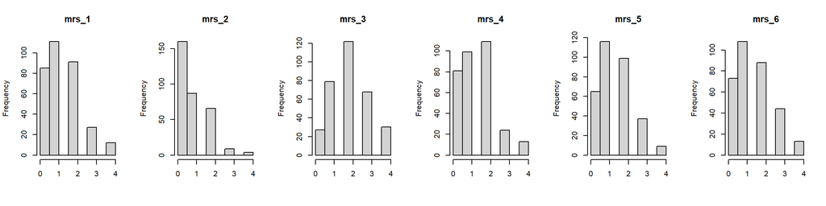

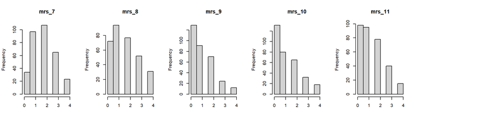

```r
# selecting columns
cols <- paste0("mrs_",1:11)

# plotting raw item scores
par(mfrow=c(1,6)); for(coL in cols){ hist(mp[,coL],main=coL,xlab="") }
```

```r
# Cronbach's alpha and 95% CI based on Feldt method
psych::alpha(mp[,cols])$feldt
```

```
##
##    95% confidence boundaries (Feldt)
##  lower alpha upper
##   0.83  0.85  0.88
```

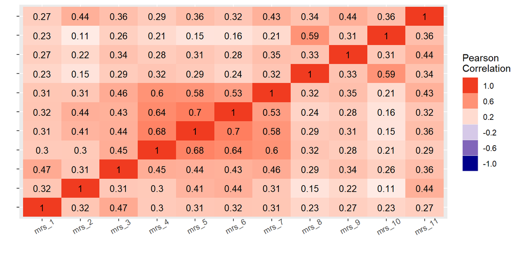

```r
# selecting columns
plot.corr(mp[,cols])
```

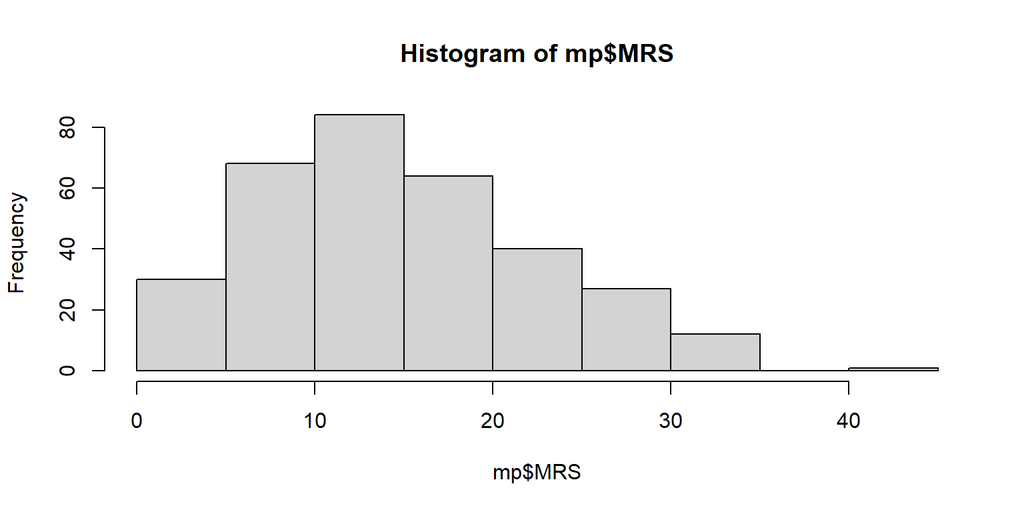

```r
# computing composite score
mp$MRS <- apply(mp[,cols],1,sum)

# visualizing composite score distribution
hist(mp$MRS)
```

### 4.1.1. MRS subscales

```r
# selecting columns
psy <- paste0("mrs_",4:7)
som <- paste0("mrs_",c(1:3,11))
urog <- paste0("mrs_",8:10)

# Cronbach's alpha and 95% CI based on Feldt method
psych::alpha(mp[,psy])$feldt # psychological
```

```
##
##    95% confidence boundaries (Feldt)
##  lower alpha upper
##   0.84  0.87  0.89
```

```r
psych::alpha(mp[,som])$feldt # somatic
```

```
##
##    95% confidence boundaries (Feldt)
##  lower alpha upper
##   0.64  0.69  0.74
```

```r
psych::alpha(mp[,urog])$feldt # urogenital
```

```
##
##    95% confidence boundaries (Feldt)
##  lower alpha upper
##   0.62  0.68  0.73
```

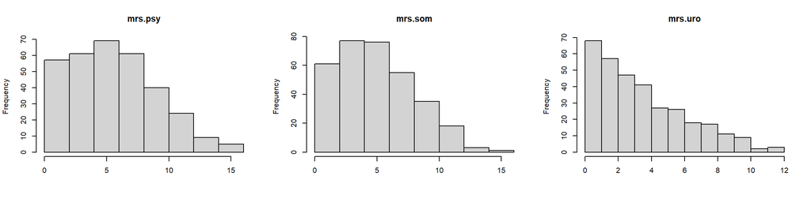

```r
# computing composite scores
mp$mrs.psy <- apply(mp[,paste0("mrs_",4:7)],1,sum)
mp$mrs.som <- apply(mp[,paste0("mrs_",c(1:3,11))],1,sum)
mp$mrs.uro <- apply(mp[,paste0("mrs_",8:10)],1,sum)

# visualizing composite score distributions
par(mfrow=c(1,3)); for(coL in paste0("mrs.",c("psy","som","uro"))) { hist(mp[,coL],main=coL,xlab="") }
```

## 4.2. Mental fog

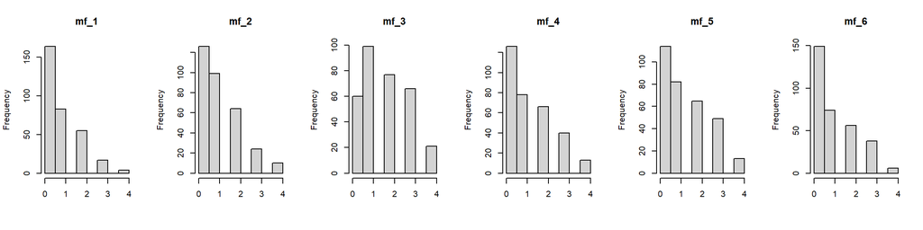

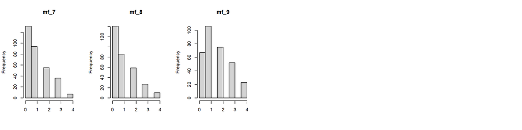

```r
# selecting columns
cols <- paste0("mf_",1:9)

# plotting raw item scores
par(mfrow=c(1,6)); for(coL in cols){ hist(mp[,coL],main=coL,xlab="") }
```

```r
# Cronbach's alpha and 95% CI based on Feldt method
psych::alpha(mp[,cols])$feldt
```

```
##
##    95% confidence boundaries (Feldt)
##  lower alpha upper
##   0.94  0.94  0.95
```

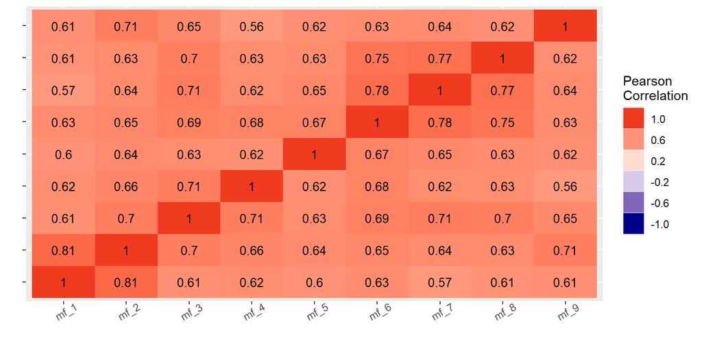

```r
# selecting columns
plot.corr(mp[,cols])
```

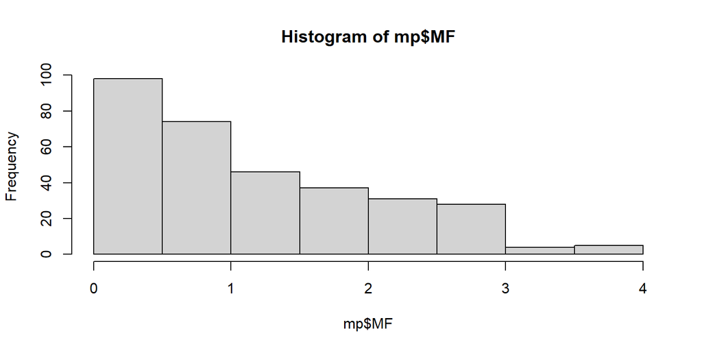

```r
# computing composite score
mp$MF <- apply(mp[,cols],1,mean,na.rm=T)

# visualizing composite score distribution
hist(mp$MF)
```

## 4.3. Workload

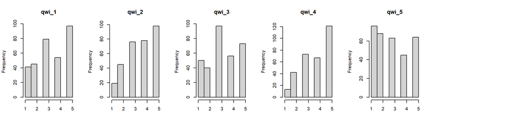

```r
# selecting columns
cols <- paste0("qwi_",1:5)

# plotting raw item scores
par(mfrow=c(1,6)); for(coL in cols){ hist(mp[,coL],main=coL,xlab="") }
```

```r
# Cronbach's alpha and 95% CI based on Feldt method
psych::alpha(mp[,cols])$feldt
```

```
##
##    95% confidence boundaries (Feldt)
##  lower alpha upper
##   0.86  0.88   0.9
```

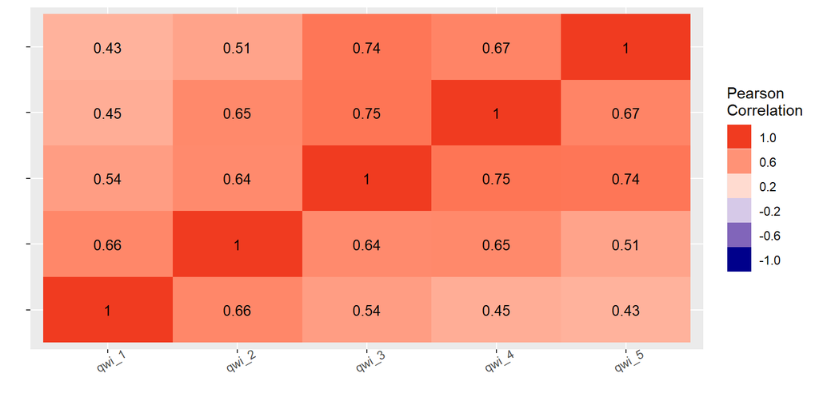

```r
# selecting columns
plot.corr(mp[,cols])
```

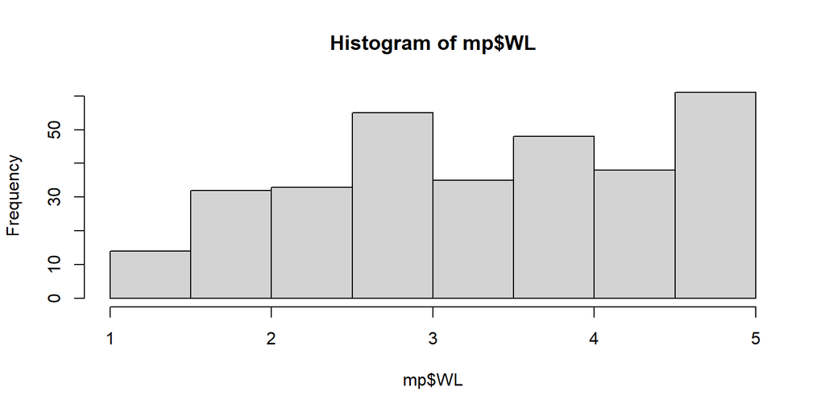

```r
# computing composite score
mp$WL <- apply(mp[,cols],1,mean,na.rm=T)

# visualizing composite score distribution
hist(mp$WL)
```

## 4.4. Work engagement

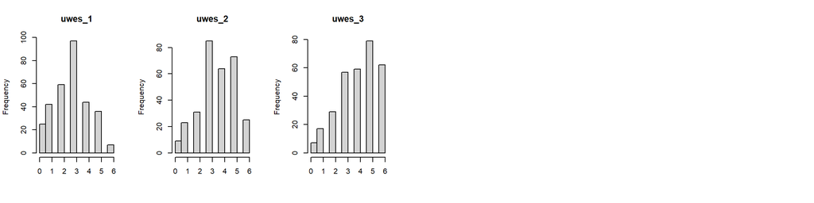

```r
# selecting columns
cols <- paste0("uwes_",1:3)

# plotting raw item scores
par(mfrow=c(1,6)); for(coL in cols){ hist(mp[,coL],main=coL,xlab="") }
```

```r
# Cronbach's alpha and 95% CI based on Feldt method
psych::alpha(mp[,cols])$feldt
```

```
##
##    95% confidence boundaries (Feldt)
##  lower alpha upper
##   0.74  0.78  0.82
```

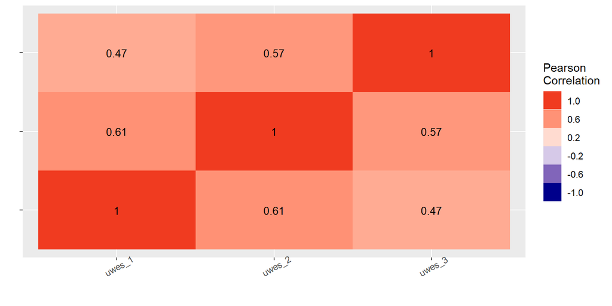

```r
# selecting columns
plot.corr(mp[,cols])
```

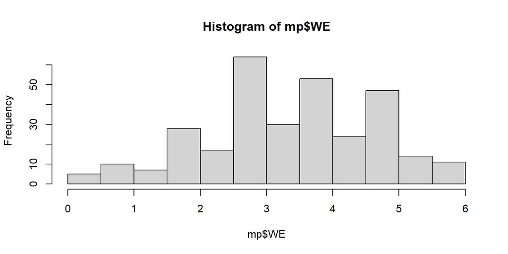

```r
# computing composite score
mp$WE <- apply(mp[,cols],1,mean,na.rm=T)

# visualizing composite score distribution
hist(mp$WE)
```

## 4.5. Emotional exhaustion

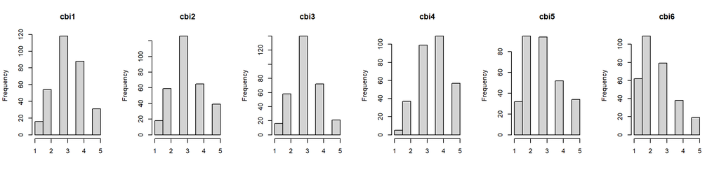

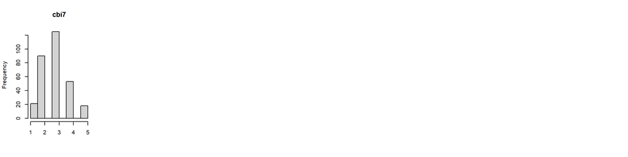

```r
# selecting columns
cols <- paste0("cbi",1:7)

# reversing item
mp$cbi7 <- 6 - mp$cbi7

# plotting raw item scores
par(mfrow=c(1,6)); for(coL in cols){ hist(mp[,coL],main=coL,xlab="") }
```

```r
# Cronbach's alpha and 95% CI based on Feldt method
psych::alpha(mp[,cols])$feldt
```

```
##
##    95% confidence boundaries (Feldt)
##  lower alpha upper
##   0.87  0.89   0.9
```

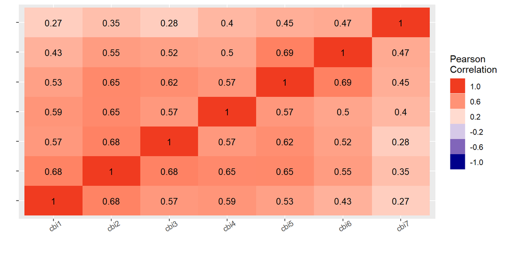

```r
# selecting columns
plot.corr(mp[,cols])
```

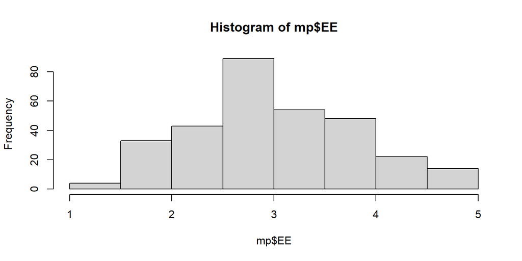

```r
# computing composite score
mp$EE <- apply(mp[,cols],1,mean,na.rm=T)

# visualizing composite score distribution
hist(mp$EE)
```

## 4.6. Turnover intentions

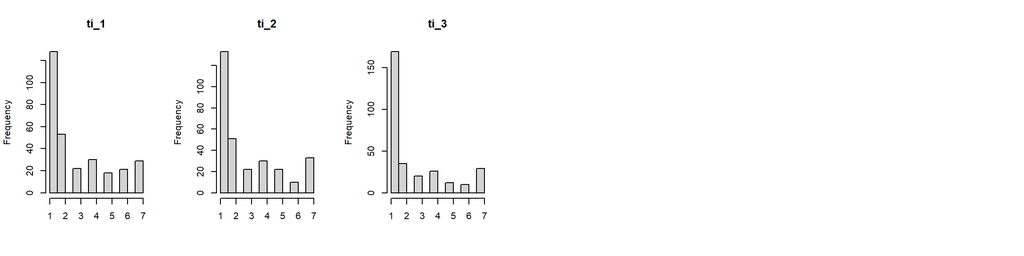

```r
# selecting columns
cols <- paste0("ti_",1:3)

# plotting raw item scores
par(mfrow=c(1,6)); for(coL in cols){ hist(mp[,coL],main=coL,xlab="") }
```

```r
# Cronbach's alpha and 95% CI based on Feldt method
psych::alpha(mp[,cols])$feldt
```

```
##
##    95% confidence boundaries (Feldt)
##  lower alpha upper
##   0.91  0.92  0.94
```

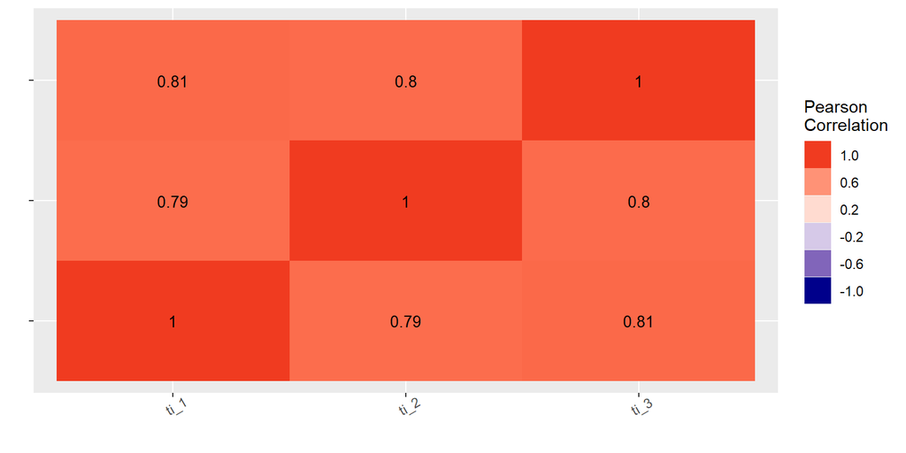

```r
# selecting columns
plot.corr(mp[,cols])
```

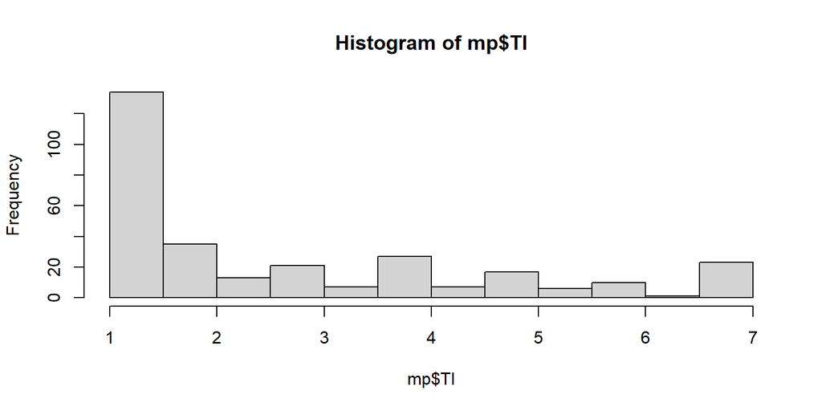

```r
# computing composite score
mp$TI <- apply(mp[,cols],1,mean,na.rm=T)

# visualizing composite score distribution
hist(mp$TI)
```

# 5. Data dictionary

Here, we remove unused variables and display the data dictionary of the dataset used in the following analyses.

```r
# removing unused variables
mp[,c(which(colnames(mp)%in%c("language","informed_consent","country","rs_none","retired")),
      which(colnames(mp)=="qwi_1"):which(colnames(mp)=="ti_3"))] <- NULL

# showing data structure
str(mp)
```

```
## 'data.frame':    351 obs. of  97 variables:
##  $ ID                    : Factor w/ 1000 levels "1","2","3","4",..: 85 87 93 95 96 97 98 99 100 101 ...
##  $ survey_timestamp      : POSIXct, format: "2023-02-01 07:20:00" "2023-02-01 10:55:52" ...
##  $ age                   : int  44 49 45 63 52 47 55 56 62 60 ...
##  $ race                  : Factor w/ 7 levels "Asian","Black",..: 7 1 7 5 7 7 2 7 7 1 ...
##  $ ethnicity             : Factor w/ 4 levels "Hispanic/Latino",..: 2 2 3 2 2 2 2 2 1 2 ...
##  $ gender                : Factor w/ 5 levels "Non-binary","NS",..: 5 5 5 5 5 5 5 5 5 5 ...
##  $ education             : Factor w/ 6 levels "Postgraduate",..: 1 6 6 1 1 6 1 1 6 6 ...
##  $ partner               : Factor w/ 2 levels "No","Yes": 2 2 2 2 2 2 2 2 2 2 ...
##  $ childcare             : Factor w/ 2 levels "No","Yes": 2 1 1 1 1 1 1 2 1 1 ...
##  $ caregiver             : Factor w/ 2 levels "No","Yes": 1 1 1 2 1 1 1 1 1 2 ...
##  $ health_conditions     : Factor w/ 2 levels "No","Yes": 1 2 1 1 1 2 1 1 2 2 ...
##  $ tobacco               : Factor w/ 2 levels "No","Yes": 1 1 1 1 1 1 1 1 1 1 ...
##  $ exercise              : int  7 2 1 5 1 7 5 5 2 7 ...
##  $ period_number         : int  10 15 2 0 14 0 0 0 0 0 ...
```

[output cut: 83 more lines]

## Response info

- `ID` = participant’s ID
- `survey_timestamp` = survey submission time and date

## About yourself

- `age` = participants’ age (years)
- `country` = participants’ country
- `race`, `ethnicity` = participants’ race and ethnicity
- `gender` = participants’ gender
- `education` = education level (Postgraduate, Undergraduate, etc.)
- `partner` = being in a romantic relationshi (Yes/No)
- `childcare` = currently taking care of 1+ children (Yes/No)
- `caregiver` = currently being a caregiver for an adult (parents, relatives, etc.) (Yes/No)
- `health_condition` = currently suffering fro an health condition (Yes/No)
- `tobacco` = being a smoker (Yes/No)
- `exercise` = No. of physical exercise sessions per week (1-7)

## Menopause experience

- `mp_knowledge` = self-reported knowledge about menopause (from 0 = Nothing to 4 = extremely knowledgeable)
- `mrs_1` - `mrs_11` = scores at the MRS symptoms (0-4) as ordered in the survey
- `mrs_impact` = perceived impact of the selected menopause symptoms on respondent’s work life
- `mf_1` - `mf_9` = scores at the mental fatigue scale (0-4) as ordered in the survey
- `mf_impact` = perceived impact of the selected menopause symptoms on respondent’s work life

## About your job

- `job_recoded` = recoded occupational group (using ISCO classification)
- `job_level` = job level/position (employee, executive, employer)
- `weeklyWorkHours` = weekly working hours (No. of working hours per week)
- `NightShift_onCall` = doing nightshift work or on call job (Yes/No)
- `remote_work` = doing remote work (Remote, Onsite, Hybrid)

## Work experience

- `workProblems_1` - `workProblems_8` = menopause-related work problems as reported in the survey (0 = no, 1 = yes)
- `workProblems_9` = participant reporting “None of these options apply to me” (0 = no, 1 = yes)

## Menopause support

- `measures_1_helpful` - `measures_9_helpful` = organizational measures considered as helpful/desired (0 = no, 1 = yes)
- `measures_1_implemented` - `measures_9_implemented` = organizational measures already implemented in the respondent’s workplace (0 = no, 1 = yes)
- `concerns_1` - `concerns_9` = concerns about discussing menopause at work (0 = no, 1 = yes)
- `concerns_0` = participant reporting “no concerns about discussing menopause at work” (0 = no, 1 = yes)

# 6. Descriptives

Here, we summarize the descriptive statistics of the sample, including the survey completion rate as well as univariate and bivariate descriptives.

## 6.1. Completion rate

Here, we inspect the overall survey completion rate and that of each section of the survey. Note that all participants completed the “About yourself” and the “Reproductive history” sections.

```r
cat(nrow(mp[!is.na(mp$survey_timestamp),]),"complete over",nrow(mp),"responses,",
    round(100*nrow(mp[!is.na(mp$survey_timestamp),])/nrow(mp),1),"%")
```

```
## 289 complete over 351 responses, 82.3 %
```

```r
# No. of responses per section
mp[!is.na(mp$rs_none),"scr"] <- "1-yourSelf-reproHistory"
mp[!is.na(mp$mrs_impact),"scr"] <- "2-menopauseRating"
mp[!is.na(mp$mf_impact),"scr"] <- "3-mentalFog"
mp[!is.na(mp$qwi_5),"scr"] <- "4-yourJob"
mp[!is.na(mp$workProblems_9),"scr"] <- "5-WorkExp"
mp[!is.na(mp$money_spent),"scr"] <- "6-Full"
p <- table(as.factor(mp$scr))
for(i in (length(p)-1):1){ p[i] <- p[i] + p[i+1]}
p # No. of responses
```

```
##
## 2-menopauseRating       3-mentalFog         5-WorkExp
##               326               323               301
```

```r
round(100*p/nrow(mp),1) # % of responses
```

```
##
## 2-menopauseRating       3-mentalFog         5-WorkExp
##              92.9              92.0              85.8
```